# Avances Pr2_Ad2

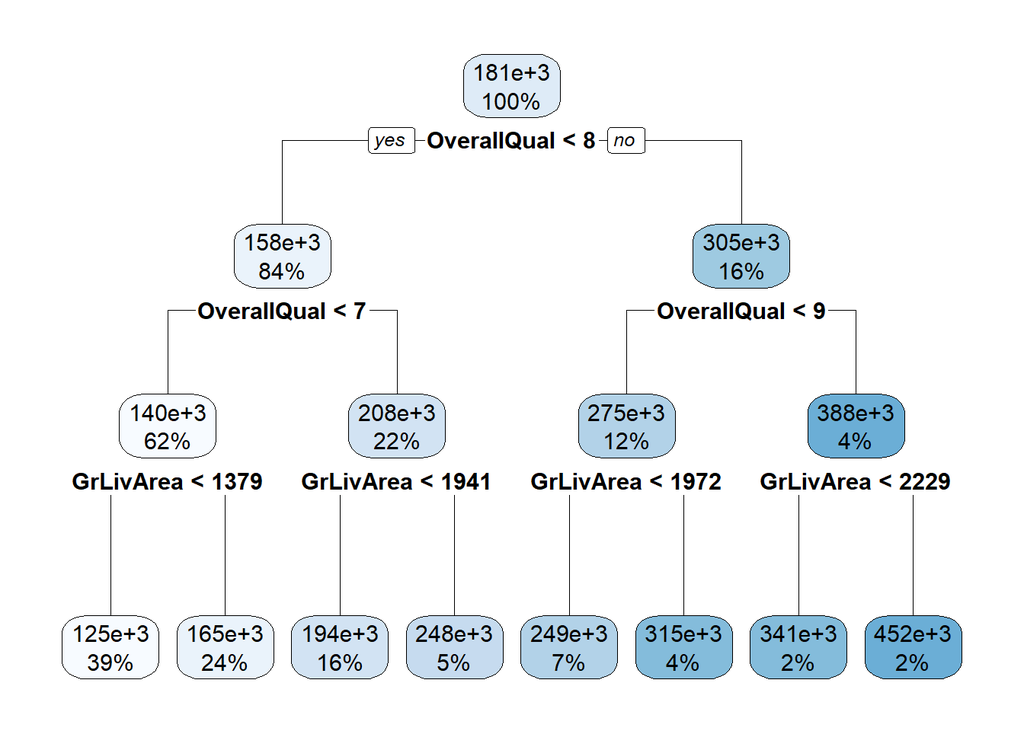

```r
rpart.plot(modelo9$finalModel)
```

```r
predModelo9 <- predict(modelo9, newdata = datos)
rmseModelo9test<-RMSE(predModelo9,mergeprice)
mseModelo9test<-mean((predModelo9 - mergeprice)^2)

predModelo9Train <- predict(modelo9, newdata = train)
rmseModelo9train<-RMSE(predModelo9Train,train$SalePrice)
mseModelo9train<-mean((predModelo9Train - train$SalePrice)^2)
```

```r
mseModelo9test
```

```
## [1] 4741037550
```

```r
mseModelo9train
```

```
## [1] 1706990759
```

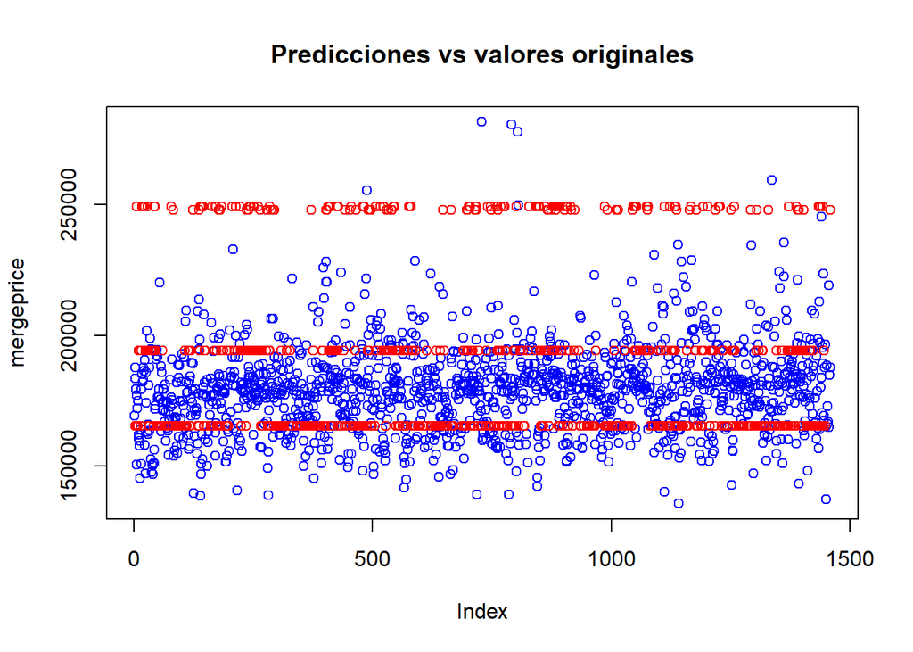

```r
plot(mergeprice,col="blue", main="Predicciones vs valores originales")
points(predModelo9, col="red")
legend(30,45,legend=c("original", "prediccion"),col=c("blue", "red"),pch=1, cex=0.8)
```

```r
modeloRF1<-randomForest(SalePrice~.,data=train)
prediccionRF1<-predict(modeloRF1,newdata = datos)
rmseModelo10test<-RMSE(prediccionRF1,mergeprice)
mseModelo10test<-mean((prediccionRF1 - mergeprice)^2)

prediccionRF1Train<-predict(modeloRF1,newdata = datos)
rmseModelo10train<-RMSE(prediccionRF1Train,train$SalePrice)
mseModelo10train<-mean((prediccionRF1Train - train$SalePrice)^2)
mseModelo10test
```

```
## [1] 4731196302
```

```r
mseModelo10train
```

```
## [1] 11338402180
```

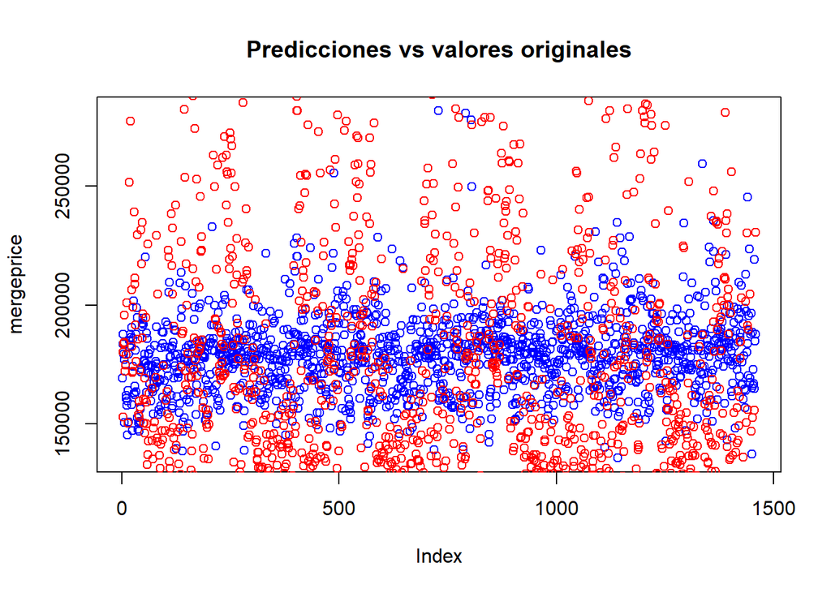

```r
plot(mergeprice,col="blue", main="Predicciones vs valores originales")
points(prediccionRF1, col="red")
legend(30,45,legend=c("original", "prediccion"),col=c("blue", "red"),pch=1, cex=0.8)
```

```r
CompModelos<-c(rmseModelo6.1test,rmseModelo7.1test,rmseModelo8test,rmseModelo9test,rmseModelo10test)
names(CompModelos)<-c("Tuneado Modelo1","Tuneado Modelo2","Tuneado Modelo3", "Tuneado Modelo4","Modelo Random Forest")
CompModelos
```

```
##      Tuneado Modelo1      Tuneado Modelo2      Tuneado Modelo3
##             76444.36             76444.36             76444.36
##      Tuneado Modelo4 Modelo Random Forest
##             68855.19             68783.69
```

Con la comparación de los 4 modelos utilizados con tuneo y el modelo de Random Forest podemos observar gráficamente con el modelo de Random Forest que tiene pocas asimilacióes con el modelo pero observamos que los modelo tuneado tienen mayor rmse a comparación del modelo de Random Forest. POr lo tanto inferimos aunque tenga menor rmse que el modelo 1 y 2, observamos que es mejor tener el modelo de Random Forest ya que no tiene overfitting de datos y esta cerca del rango de los modelos de tuneado.